# VISUALISATION OF THE DANGER ABOUT THE SPREAD OF CORONA VIRUS IN INDIA

BARNALIKKA PRADHAN (19060242014)

```r
attach(time_series)
View(time_series)
str(time_series)
```

```
Classes ‘tbl_df’, ‘tbl’ and 'data.frame':   43 obs. of  5 variables:
 $ Date           : POSIXct, format: "2020-02-15" "2020-02-16" "2020-02-17" "2020-02-18" ...
 $ Total Cases    : num  0 3 3 3 3 3 3 3 3 3 ...
 $ Daily New Cases: num  0 0 0 0 0 0 0 0 0 0 ...
 $ Total Deaths   : num  0 0 0 0 0 0 0 0 0 0 ...
 $ Recovery       : num  0 0 0 0 0 0 0 0 0 0 ...
```

```r
summary(time_series)
```

```
      Date                      Total Cases    Daily New Cases   Total Deaths      Recovery
 Min.   :2020-02-15 00:00:00   Min.   :  0.0   Min.   :  0.00   Min.   : 0.00   Min.   : 0.000
 1st Qu.:2020-02-25 12:00:00   1st Qu.:  3.0   1st Qu.:  0.00   1st Qu.: 0.00   1st Qu.: 0.000
 Median :2020-03-07 00:00:00   Median : 34.0   Median :  3.00   Median : 0.00   Median : 0.000
 Mean   :2020-03-07 00:00:00   Mean   :155.1   Mean   : 22.88   Mean   : 3.07   Mean   : 1.884
 3rd Qu.:2020-03-17 12:00:00   3rd Qu.:156.0   3rd Qu.: 23.50   3rd Qu.: 3.00   3rd Qu.: 1.000
 Max.   :2020-03-28 00:00:00   Max.   :987.0   Max.   :160.00   Max.   :24.00   Max.   :28.000
```

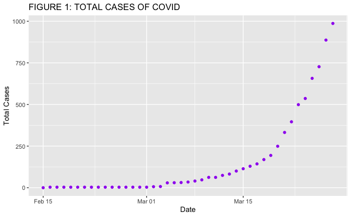

```r
library(ggplot2)
ggplot(time_series,aes(x=Date,y=`Total Cases`))+geom_point(colour="purple")+labs(title = "FIGURE 1: TOTAL CASES OF COVID")
```

# QUESTION (i)

It is clearly visible in FIGURE 1, while plotting the specific dates against the total cases in ggplot we see an upsurge in the total number of cases of COVID from 15th March onwards, having recorded a total of 114 cases on that particular day, rising upto 987 total cases as of 28th March 2020 in India.

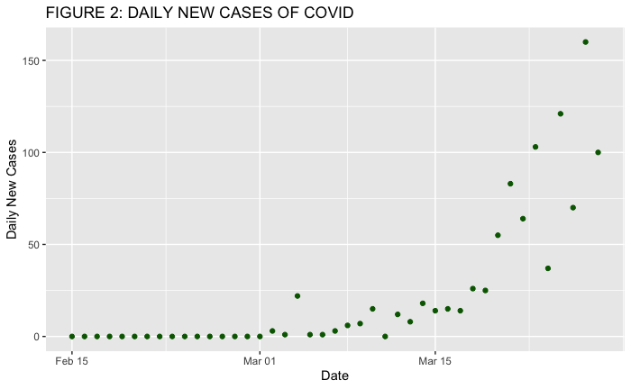

```r
ggplot(time_series,aes(x=Date,y=`Daily New Cases`))+geom_point(colour="darkgreen")+labs(title = "FIGURE 2: DAILY NEW CASES OF COVID")
```

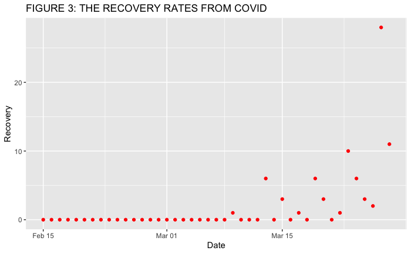

```r
ggplot(time_series,aes(x=Date,y=`Recovery`))+geom_point(colour="red")+labs(title = "FIGURE 3: THE RECOVERY RATES FROM COVID")
```

In the above FIGURE 3 , we see the recovery rates in India aren’t very high. On 9th March, out of the total 47 cases of COVID existing in India, the recovery rate is just 1, but on the 13th March the recovery rate jumped to a number of 6, with certain fluctuations in numbers likewise, followed by an increase in the recovery rate to 10 as of 23rd March.The highest recovery rate was on 27th March, a total of 28 patients recovered from COVID on that particular day.

# QUESTION (ii)

India having a high population density,is more susceptible to COVID so therefore the lock-down measures as a means of keeping social distancing is effective to check the spread of corona, as it will reduce contact between the people,eventually preventing the transmission of the contagious disease from one person to the other. Also during this period of lockdown, it becomes easier to track the people infected,impose quarantines and reduce fatalities. Extensive measures to find, isolate,test,treat and trace seems to be the best option to control COVID in India.

```r
attach(age_specific)
View (age_specific)
str(age_specific)
```

```
Classes ‘tbl_df’, ‘tbl’ and 'data.frame':   9 obs. of  2 variables:
 $ Age Group : chr  "0 - 9 Years" "10 - 19 Years" "20 -29 Years" "30 - 39 Years" ...
 $ Death Rate: num  0 0.2 0.2 0.2 0.4 1.3 3.6 8 14.8
```

```r
summary(age_specific)
```

```
  Age Group           Death Rate
 Length:9           Min.   : 0.000
 Class :character   1st Qu.: 0.200
 Mode  :character   Median : 0.400
                    Mean   : 3.189
                    3rd Qu.: 3.600
                    Max.   :14.800
```

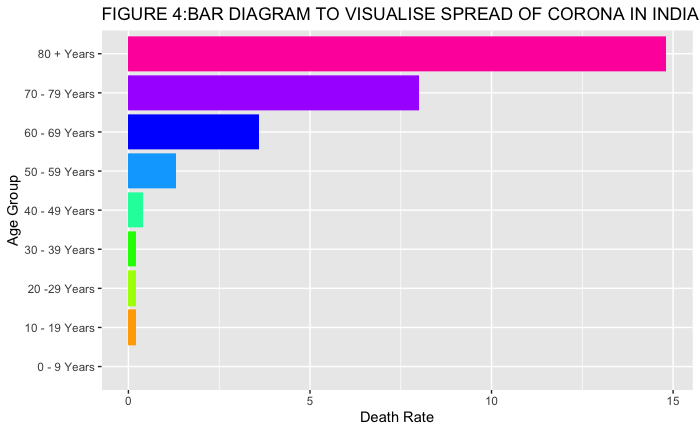

```r
library(ggplot2)
ggplot(age_specific, aes(x = `Age Group`, y=`Death Rate`))+ geom_bar(stat="identity",fill=rainbow(9))+coord_flip()+labs(title = "FIGURE 4:BAR DIAGRAM TO VISUALISE SPREAD OF CORONA IN INDIA")
```

# QUESTION (iii)

In the above bar diagram, figure 4, we can clearly see that Corona has led to increase in death of people 60 years and above, but the highest death to be recorded is of the elderly people age 80+ standing at 14.8%. Since their immune system is extreme low the elderly people are at a higher risk of being exposed to the deadly virus.